# Report on the stochastic model for Georgia with the inclusion of a latent trend in transmission rate

Andrew Tredennick

27 May, 2020

## Overview

The current *Georgia stochostic model* of COVID-19 tranmission incorporates a metric of human movement ($\phi(t)$) that moderates the baseline tranmission rate ($\beta$): $\beta(t) = \phi(t)\beta$. This formulation is meant to represent the impact of social distancing. Social distancing, while powerful, is not the only practice that can reduce transmission. Other practices, such as wearing face coverings, maintaining social distance in public spaces, and enhanced cleaning practices, can also reduce transmission. These practices are difficult to quantify in data and, in turn, are difficult to model explicitly. Nonetheless, we expect that mobility data will become less informative of transmission over time and that other practices will play a larger role.

I used a basis function approach (spline modeling) to model a latent temporal process that mediates baseline tranmission rate. The idea is to include a smooth temporal function in the model that stands in for all unobserved processes that can reduce transmission.

Here I report on models fit to the most recent data and projections from the fitted models.

## Results

### Estimated latent trend in tranmission

The MLE parameters lead to the following latent trend.

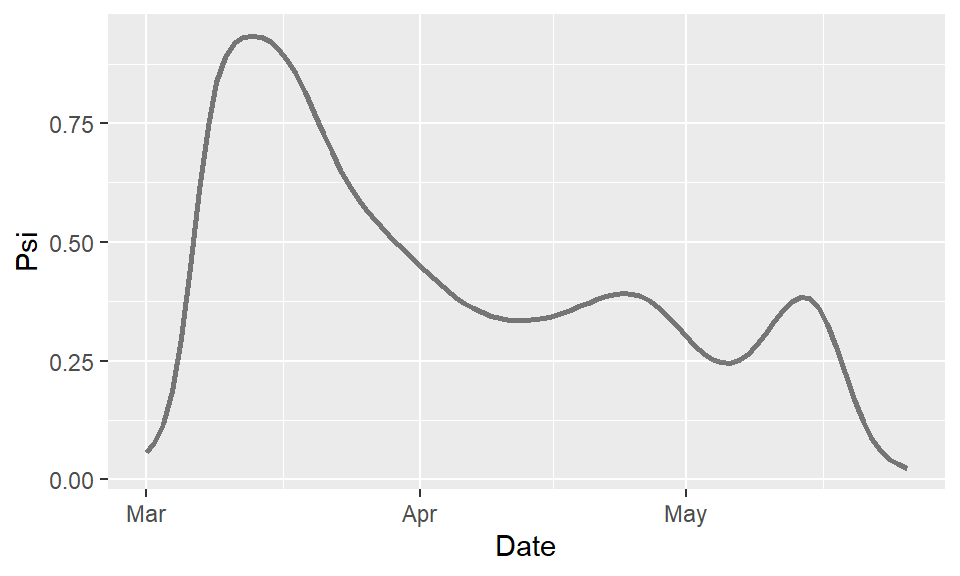

### Variability in other parameter values across MLE sets

| MLE set | LogLik | LogLik_SE | beta_s | max_detect_frac | frac_hosp | frac_dead | theta_cases | theta_hosps | theta_deaths | sigma_dw |
| --- | --- | --- | --- | --- | --- | --- | --- | --- | --- | --- |
| 1 | -813.04 | 0.35 | 0.86 | 0.4 | 0.12 | 0.55 | 7.38 | 10 | 2.31 | 0.00 |
| 2 | -813.17 | 0.12 | 0.83 | 0.4 | 0.12 | 0.48 | 7.34 | 10 | 2.59 | 0.00 |
| 3 | -814.19 | 0.14 | 0.82 | 0.4 | 0.12 | 0.53 | 6.30 | 10 | 2.01 | 0.00 |
| 4 | -814.58 | 0.07 | 0.68 | 0.4 | 0.12 | 0.51 | 6.05 | 10 | 2.33 | 0.02 |
| 5 | -814.88 | 0.08 | 0.93 | 0.4 | 0.12 | 0.52 | 6.95 | 10 | 2.44 | 0.02 |
| 6 | -814.97 | 0.08 | 0.84 | 0.4 | 0.12 | 0.48 | 7.19 | 10 | 2.29 | 0.07 |
| 7 | -814.97 | 0.08 | 0.69 | 0.4 | 0.12 | 0.52 | 8.12 | 10 | 2.59 | 0.02 |

### Model fit to data

The fits look pretty good, and show more of a flattening than the current GA model (though the most recent fit of the GA model is also showing more flattening). The grey lines are the “best” for each MLE, where “best” is defined relative to the most recent data point so that the initial conditions for projection are given priority. The red line is the median; the blue line is the mean.

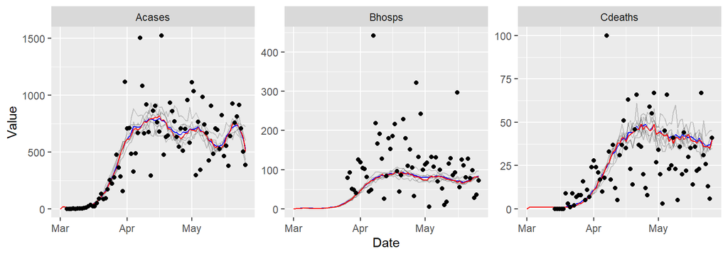

### Scenario projections

These are just some first stabs at scenario projections for the model – we’ll need to brainstorm the best approach here. I excluded the “what it social distancing had continued to increase?” counter-factual, for now. Here I list the scenarios and how they were implemented. Many ignore the latent altogether by simply repeating the final value from the observed period into the future.

1. No intervention: set both $\phi$ and $\psi$ to one, such that baseline transmission is used throughout the simulation
2. Return to normal: both $\phi$ and $\psi$ return to one over a seven day period and then remain there.
3. All others: $\phi$ is perturbed as per the “regular” model and $\psi$ is set to the last estimated value.

I am just going to plot the log-scale projections.

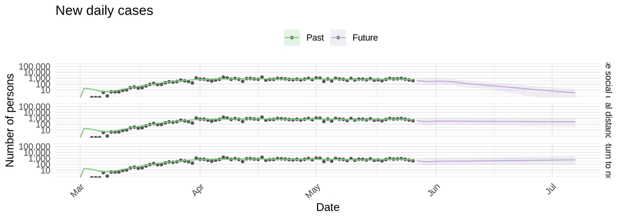

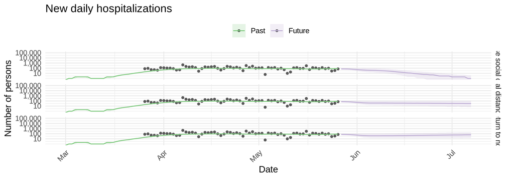

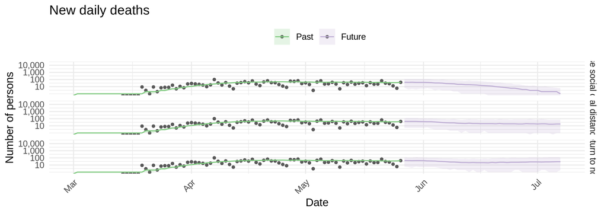

# Appendix

## Implementation

We currently model the force of infection ($f$) at time $t$ as:

$$f(t) = \phi(t)\frac{\beta}{N} (I(t)),$$

where, for simplicity, $I$ stands for all infectious individuals at time $t$. The mobility index $\phi$ looks like this:

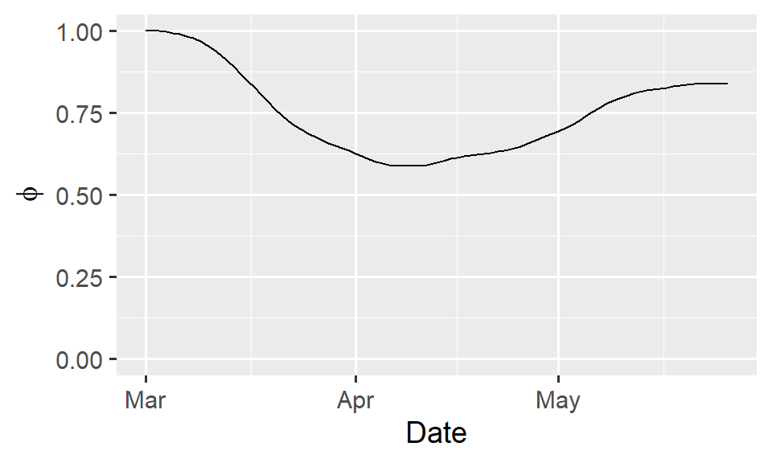

I proposed to add a temporal basis function to incorporate additional tranmission reduction over time that we cannot observe. Let the new temporal term be $\psi$, which is modeled as:

$$\text{logit}\left(\psi(t)\right) = \sum_{i=1}^K q_i \xi_{i_t},$$

where $K$ is the number of knots, $\mathbf{q}$ is a vector of spline coefficients (to be fitted), and $\mathbf{\xi}$ is a matrix basis functions. I define the number of knots ($K$) as the number of days in the data set divided by 7 (so, one knot per week). Note the logit transformation to go from the linear scale to the 0 - 1 scale. Thus, $f(t)$ becomes: $f(t) = \psi(t)\phi(t)\frac{\beta}{N} (I(t))$.

Assuming $K = 9$, the basis functions are:

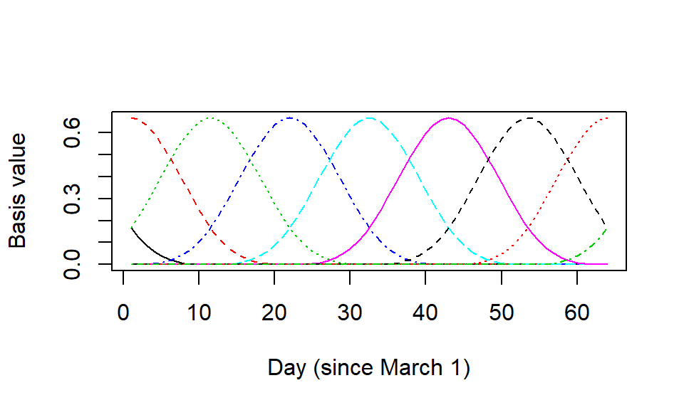

Assuming a vector of $\mathbf{q}$ values drawn from a normal distribution with mean 0 and unit variance, the resulting function can look like this:

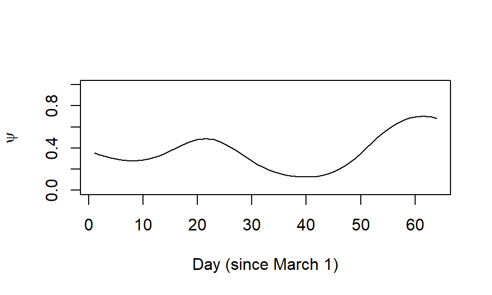